# STAT501_L1_Simple_Linear_Regression_Examples

Ada Lazuli

2025-10-25

```r
library(dplyr)
library(ggplot2)
library(qqplotr)
library(tidyr)
library(reactable)
library(openxlsx)
```

# Lesson Overview

Simple linear regression is a statistical method that allows us to summarize and study relationships between two continuous (quantitative) variables. This lesson introduces the concept and basic procedures of simple linear regression.

# Example 1-6: Teen Birth Rate and Poverty Level Data

```r
df <- read.table("./Data/STAT501_Lesson01/poverty.txt", header = T)
reactable(df,searchable = TRUE,sortable = TRUE,
          defaultPageSize = 5, bordered = TRUE, highlight = TRUE)
```

| Location | PovPct | Brth15to17 | Brth18to19 | ViolCrime | TeenBrth |
| --- | --- | --- | --- | --- | --- |
| Alabama | 20.1 | 31.5 | 88.7 | 11.2 | 54.5 |
| Alaska | 7.1 | 18.9 | 73.7 | 9.1 | 39.5 |
| Arizona | 16.1 | 35 | 102.5 | 10.4 | 61.2 |
| Arkansas | 14.9 | 31.6 | 101.7 | 10.4 | 59.9 |
| California | 16.7 | 22.6 | 69.1 | 11.2 | 41.1 |
| Colorado | 8.8 | 26.2 | 79.1 | 5.8 | 47 |
| Connecticut | 9.7 | 14.1 | 45.1 | 4.6 | 25.8 |
| Delaware | 10.3 | 24.7 | 77.8 | 3.5 | 46.3 |
| District_of_Columbia | 22 | 44.8 | 101.5 | 65 | 69.1 |
| Florida | 16.2 | 23.2 | 78.4 | 7.3 | 44.5 |

[output cut: 41 more lines]

The data has 51 observations for the 50 states and DC. The $y$ axis has the births per 1000 females who are between 15 and 17. The $x$ axis has the poverty rate.

This scatter plot below shows the general trend.

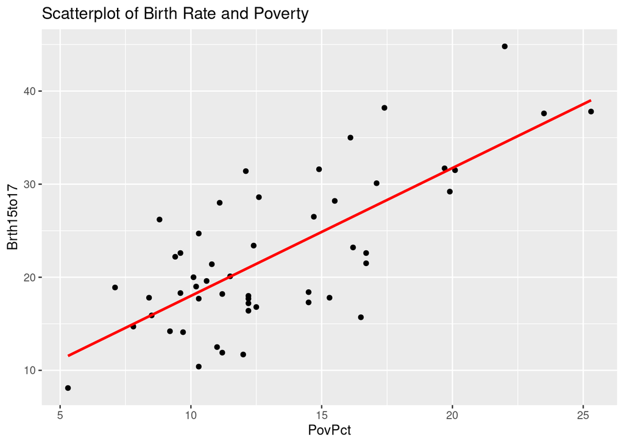

```r
ggplot(df, aes(x=PovPct, y=Brth15to17)) + geom_point() +
  geom_smooth(method = "lm", se = FALSE, color ="red") +
  ggtitle("Scatterplot of Birth Rate and Poverty")
```

The scatterplot shows that there is a general positive linear trend.

```r
model <- lm(Brth15to17 ~ PovPct, data=df)
summary(model)
```

```
##
## Call:
## lm(formula = Brth15to17 ~ PovPct, data = df)
##
## Residuals:
##      Min       1Q   Median       3Q      Max
## -11.2275  -3.6554  -0.0407   2.4972  10.5152
##
## Coefficients:
##             Estimate Std. Error t value Pr(>|t|)
## (Intercept)   4.2673     2.5297   1.687    0.098 .
## PovPct        1.3733     0.1835   7.483 1.19e-09 ***
## ---
## Signif. codes:  0 '***' 0.001 '**' 0.01 '*' 0.05 '.' 0.1 ' ' 1
##
## Residual standard error: 5.551 on 49 degrees of freedom
## Multiple R-squared:  0.5333, Adjusted R-squared:  0.5238
## F-statistic:    56 on 1 and 49 DF,  p-value: 1.188e-09
```

### Interpretations

The $R^2$ for this model is 0.5333, which means that $53.3%$ of the variation in birthrate is explained by poverty rate.

The interpretation of the slope (value = 1.373) is that the 15 to 17-year-old birth rate increases by 1.373 units, on average, for each unit (one percent) increase in the poverty rate.

The interpretation of the intercept (value=4.267) is that if there were states with a poverty rate = 0, the predicted average for the 15 to 17-year-old birth rate would be 4.267 for those states. Since there are no states with a poverty rate = 0 this interpretation of the intercept is not practically meaningful for this example.